# Portland Real Estate Market Statistical Modelling and Analysis (R)

```r
library(ggplot2) # For some amazing looking graphs
library(MASS) # Library for our box-cox transform down the end
library(corrplot) # Plotting nice correlation matrix
library(dplyr) # Library for splitting train & test data set
library(GGally)
library(mctest) #For VIF
library(olsrr)
library(MASS) #Box-cox
library(lmtest) # Bptest
library(pastecs)
```

## Data Cleaning and Preparation

```r
portland = read.csv('C:\\Users\\Chang Sun\\Desktop\\DATA603\\Project\\Portland.csv')
head(portland)
```

|  | SALE.TYPE | PROPERTY.TYPE | CITY | ZIP.OR.POSTAL.CODE | PRICE | BEDS | BATHS | LOCATION | SQUARE.FEET | LOT.SIZE | YEAR.BUILT | DAYS.ON.MARKET | PERSQUARE.FEET | HOA.MONTH | STATUS |
| --- | --- | --- | --- | --- | --- | --- | --- | --- | --- | --- | --- | --- | --- | --- | --- |
| 1 | MLS Listing | Condo/Co-op | Portland | 97221 | 500000 | 2 | 1.0 | Wilcox Manor | 2081 | NA | 1917 | 4 | 240 | 1146 | Active |
| 2 | MLS Listing | Condo/Co-op | Portland | 97206 | 275000 | 1 | 1.0 | RICHMOND | 605 | NA | 1949 | 4 | 455 | 347 | Active |
| 3 | MLS Listing | Condo/Co-op | Portland | 97266 | 298000 | 3 | 2.5 | Portland Southeast | 1418 | NA | 2005 | 4 | 210 | 55 | Active |
| 4 | MLS Listing | Single Family Residential | Portland | 97233 | 325000 | 4 | 2.0 | Portland Southeast | 2570 | 4356 | 1927 | 5 | 126 | NA | Active |
| 5 | MLS Listing | Condo/Co-op | Portland | 97209 | 274900 | 1 | 1.0 | ALPHABET DISTRICT | 424 | NA | 1906 | 5 | 648 | 293 | Active |
| 6 | MLS Listing | Condo/Co-op | Portland | 97232 | 269000 | 1 | 1.0 | Portland Northeast | 617 | NA | 2001 | 18 | 436 | 340 | Active |

```r
names(portland)
```

```
##  [1] "SALE.TYPE"          "PROPERTY.TYPE"      "CITY"
##  [4] "ZIP.OR.POSTAL.CODE" "PRICE"              "BEDS"
##  [7] "BATHS"              "LOCATION"           "SQUARE.FEET"
## [10] "LOT.SIZE"           "YEAR.BUILT"         "DAYS.ON.MARKET"
## [13] "PERSQUARE.FEET"     "HOA.MONTH"          "STATUS"
```

```r
sapply(portland, function(x) sum(is.na(x)))
```

```
##          SALE.TYPE      PROPERTY.TYPE               CITY ZIP.OR.POSTAL.CODE
##                  0                  0                  0                  0
##              PRICE               BEDS              BATHS           LOCATION
##                  0                 22                 22                  0
##        SQUARE.FEET           LOT.SIZE         YEAR.BUILT     DAYS.ON.MARKET
##                 25                170                 21                  0
##     PERSQUARE.FEET          HOA.MONTH             STATUS
##                 25                172                  0
```

```r
#Remove records with NA values
nrow(portland)
```

```
## [1] 350
```

```r
portland <- portland[-which(is.na(portland$SQUARE.FEET)),]
nrow(portland)
```

```
## [1] 325
```

```r
sapply(portland, function(x) sum(is.na(x)))
```

```
##          SALE.TYPE      PROPERTY.TYPE               CITY ZIP.OR.POSTAL.CODE
##                  0                  0                  0                  0
##              PRICE               BEDS              BATHS           LOCATION
##                  0                  0                  0                  0
##        SQUARE.FEET           LOT.SIZE         YEAR.BUILT     DAYS.ON.MARKET
##                  0                165                  0                  0
##     PERSQUARE.FEET          HOA.MONTH             STATUS
##                  0                154                  0
```

```r
#Extract columns of interest
portland <- portland[,-c(1,3,4,8,10,13,14,15)]
```

```r
format((stat.desc(portland)),scientific=F,digits=0)
```

|  | PROPERTY.TYPE | PRICE | BEDS | BATHS | SQUARE.FEET | YEAR.BUILT | DAYS.ON.MARKET |
| --- | --- | --- | --- | --- | --- | --- | --- |
| nbr.val | NA | 325 | 325 | 325 | 325 | 325 | 325 |
| nbr.null | NA | 0 | 6 | 0 | 0 | 0 | 0 |
| nbr.na | NA | 0 | 0 | 0 | 0 | 0 | 0 |
| min | NA | 205000 | 0 | 0 | 424 | 1890 | 1 |
| max | NA | 600000 | 6 | 4 | 3704 | 2021 | 146 |
| range | NA | 395000 | 6 | 4 | 3280 | 131 | 145 |
| sum | NA | 134145470 | 763 | 552 | 434952 | 640671 | 4077 |
| median | NA | 405000 | 2 | 2 | 1231 | 1977 | 11 |
| mean | NA | 412755 | 2 | 2 | 1338 | 1971 | 13 |
| SE.mean | NA | 5723 | 0 | 0 | 34 | 2 | 1 |

[output cut: 4 more lines]

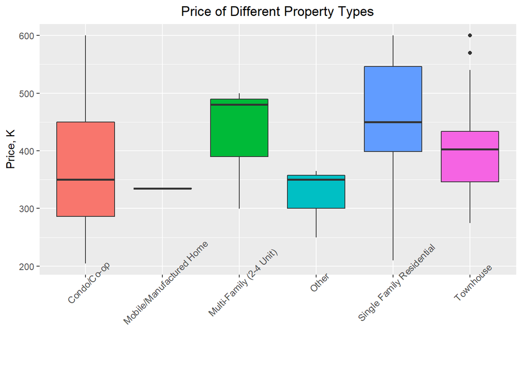

```r
#boxplot(PRICE/1000~PROPERTY.TYPE,data = portland,las=2,cex.axis=0.7)
ggplot(portland, aes(x=PROPERTY.TYPE, y=PRICE/1000, fill=PROPERTY.TYPE)) +geom_boxplot() + ggtitle("Price of Different Property Types") +ylab("Price, K")+theme(axis.title.x = element_blank(),axis.text.x = element_text(size = 9,angle = 45),legend.title = element_blank(),legend.position = "none",plot.title = element_text(hjust = 0.5))
```

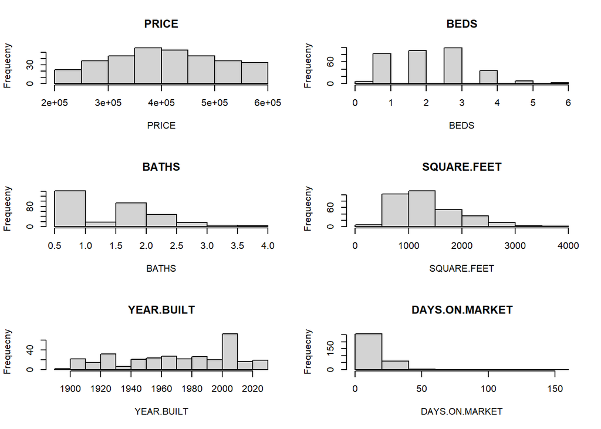

```r
par(mfrow = c(3,2))  # Set up a 2 x 2 plotting space
loop.vector <- 1:6 # Create the loop.vector (all the columns)
for (i in 2:ncol(portland)) { # Loop over loop.vector
  # store data in column.i as x
  x <- portland[,i]
    # Plot histogram of x
  hist(x,main = colnames(portland)[i],xlab = colnames(portland)[i],ylab='Frequecny')
}
```

```r
#Seperate data to training set and test set
set.seed(2021)
sample <- sample.int(n = nrow(portland), size = floor(0.8*nrow(portland)), replace = F)
train <- portland[sample, ]
test  <- portland[-sample, ]
head(train)
```

|  | PROPERTY.TYPE | PRICE | BEDS | BATHS | SQUARE.FEET | YEAR.BUILT | DAYS.ON.MARKET |
| --- | --- | --- | --- | --- | --- | --- | --- |
| 175 | Single Family Residential | 550000 | 5 | 2 | 2295 | 1956 | 8 |
| 250 | Condo/Co-op | 239000 | 1 | 1 | 697 | 2007 | 18 |
| 71 | Single Family Residential | 600000 | 3 | 3 | 1920 | 1939 | 4 |
| 207 | Condo/Co-op | 265000 | 1 | 1 | 592 | 1949 | 12 |
| 271 | Condo/Co-op | 329000 | 3 | 2 | 1115 | 1970 | 19 |
| 103 | Condo/Co-op | 240000 | 1 | 1 | 602 | 1966 | 5 |

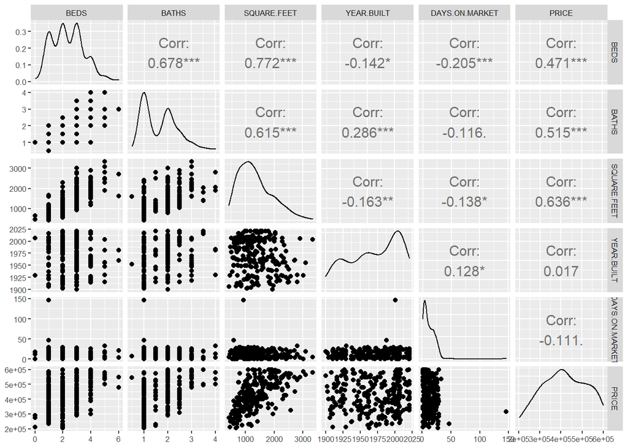

```r
ggpairs(train,columns = c(3,4,5,6,7,2), upper = list(continuous = wrap("cor", size = 4)))+ theme_grey(base_size = 8)
```

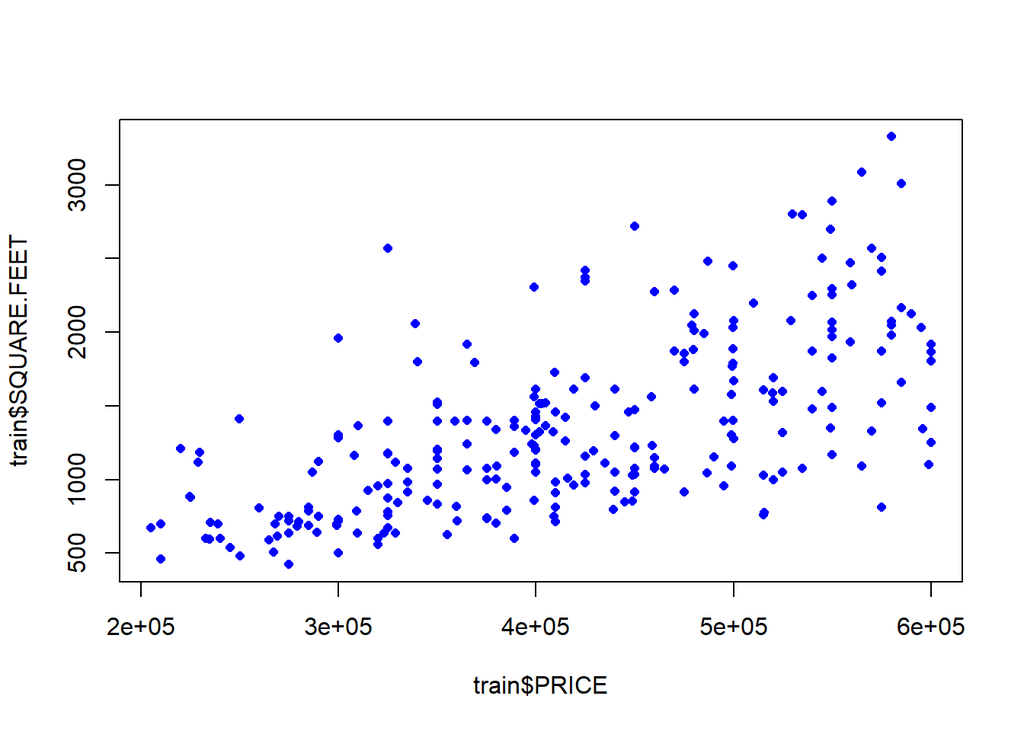

```r
plot(train$PRICE, train$SQUARE.FEET, pch = 16, cex = 0.8, col = "blue")
```

```r
corPlot <- portland[, c(2,5,3,4,7,6)]
# print the first 6 rows
head(corPlot, 6)
```

|  | PRICE | SQUARE.FEET | BEDS | BATHS | DAYS.ON.MARKET | YEAR.BUILT |
| --- | --- | --- | --- | --- | --- | --- |
| 1 | 500000 | 2081 | 2 | 1.0 | 4 | 1917 |
| 2 | 275000 | 605 | 1 | 1.0 | 4 | 1949 |
| 3 | 298000 | 1418 | 3 | 2.5 | 4 | 2005 |
| 4 | 325000 | 2570 | 4 | 2.0 | 5 | 1927 |
| 5 | 274900 | 424 | 1 | 1.0 | 5 | 1906 |
| 6 | 269000 | 617 | 1 | 1.0 | 18 | 2001 |

```r
corResult=cor(corPlot, use = "complete.obs")
round(corResult,2)
```

```
##                PRICE SQUARE.FEET  BEDS BATHS DAYS.ON.MARKET YEAR.BUILT
## PRICE           1.00        0.65  0.50  0.51          -0.13       0.01
## SQUARE.FEET     0.65        1.00  0.75  0.61          -0.15      -0.13
## BEDS            0.50        0.75  1.00  0.68          -0.21      -0.08
## BATHS           0.51        0.61  0.68  1.00          -0.14       0.31
## DAYS.ON.MARKET -0.13       -0.15 -0.21 -0.14           1.00       0.08
## YEAR.BUILT      0.01       -0.13 -0.08  0.31           0.08       1.00
```

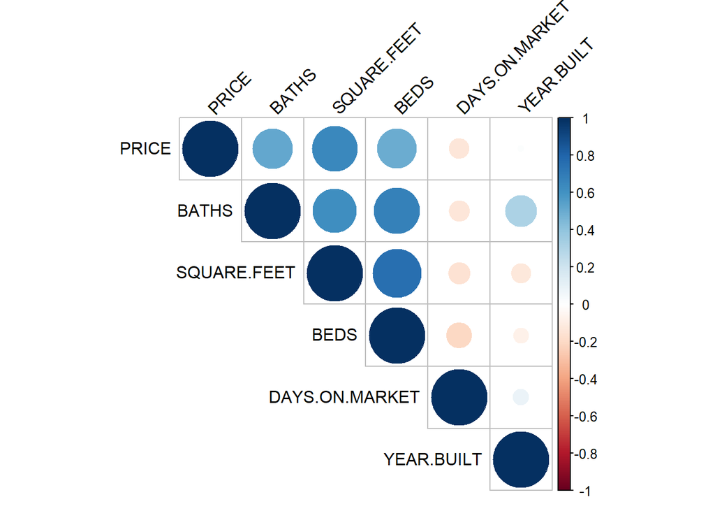

```r
corrplot(corResult, type = "upper", order = "hclust",
         tl.col = "black", tl.srt = 45)
```

## First Order Model

```r
#Check multicolinearity
fitAllModel <- lm(PRICE~.,data = train)
imcdiag(fitAllModel, method="VIF")
```

```
##
## Call:
## imcdiag(mod = fitAllModel, method = "VIF")
##
##
##  VIF Multicollinearity Diagnostics
##
##                                           VIF detection
## PROPERTY.TYPEMobile/Manufactured Home  1.0309         0
## PROPERTY.TYPEMulti-Family (2-4 Unit)   1.2908         0
## PROPERTY.TYPEOther                     1.0386         0
## PROPERTY.TYPESingle Family Residential 2.8936         0
## PROPERTY.TYPETownhouse                 1.1686         0
## BEDS                                   4.6627         0
## BATHS                                  2.9265         0
## SQUARE.FEET                            2.9254         0
## YEAR.BUILT                             1.6733         0
## DAYS.ON.MARKET                         1.1186         0
##
## NOTE:  VIF Method Failed to detect multicollinearity
##
##
## 0 --> COLLINEARITY is not detected by the test
##
## ===================================
```

```r
forwardModel <- ols_step_forward_p(fitAllModel, pent=0.05, details=F)
summary(forwardModel$model)
```

```
##
## Call:
## lm(formula = paste(response, "~", paste(preds, collapse = " + ")),
##     data = l)
##
## Residuals:
##     Min      1Q  Median      3Q     Max
## -210376  -53876   -6964   49070  219064
##
## Coefficients:
##              Estimate Std. Error t value Pr(>|t|)
## (Intercept) 247697.63   13343.89  18.563  < 2e-16 ***
## SQUARE.FEET    108.98      13.28   8.209 1.10e-14 ***
## BATHS        36129.16    9132.64   3.956 9.87e-05 ***
## BEDS        -16165.69    7278.22  -2.221   0.0272 *
## ---
## Signif. codes:  0 '***' 0.001 '**' 0.01 '*' 0.05 '.' 0.1 ' ' 1
##
## Residual standard error: 77820 on 256 degrees of freedom
## Multiple R-squared:  0.4399, Adjusted R-squared:  0.4334
## F-statistic: 67.03 on 3 and 256 DF,  p-value: < 2.2e-16
```

```r
backwardModel <- ols_step_backward_p(fitAllModel, prem=0.05, details=F)
summary(backwardModel$model)
```

```
##
## Call:
## lm(formula = paste(response, "~", paste(preds, collapse = " + ")),
##     data = l)
##
## Residuals:
##     Min      1Q  Median      3Q     Max
## -210376  -53876   -6964   49070  219064
##
## Coefficients:
##              Estimate Std. Error t value Pr(>|t|)
## (Intercept) 247697.63   13343.89  18.563  < 2e-16 ***
## BEDS        -16165.69    7278.22  -2.221   0.0272 *
## BATHS        36129.16    9132.64   3.956 9.87e-05 ***
## SQUARE.FEET    108.98      13.28   8.209 1.10e-14 ***
## ---
## Signif. codes:  0 '***' 0.001 '**' 0.01 '*' 0.05 '.' 0.1 ' ' 1
##
## Residual standard error: 77820 on 256 degrees of freedom
## Multiple R-squared:  0.4399, Adjusted R-squared:  0.4334
## F-statistic: 67.03 on 3 and 256 DF,  p-value: < 2.2e-16
```

```r
StepwiseModel <- ols_step_both_p(fitAllModel, pent=0.05, prem = 0.05, details=F)
summary(StepwiseModel$model)
```

```
##
## Call:
## lm(formula = paste(response, "~", paste(preds, collapse = " + ")),
##     data = l)
##
## Residuals:
##     Min      1Q  Median      3Q     Max
## -210376  -53876   -6964   49070  219064
##
## Coefficients:
##              Estimate Std. Error t value Pr(>|t|)
## (Intercept) 247697.63   13343.89  18.563  < 2e-16 ***
## SQUARE.FEET    108.98      13.28   8.209 1.10e-14 ***
## BATHS        36129.16    9132.64   3.956 9.87e-05 ***
## BEDS        -16165.69    7278.22  -2.221   0.0272 *
## ---
## Signif. codes:  0 '***' 0.001 '**' 0.01 '*' 0.05 '.' 0.1 ' ' 1
##
## Residual standard error: 77820 on 256 degrees of freedom
## Multiple R-squared:  0.4399, Adjusted R-squared:  0.4334
## F-statistic: 67.03 on 3 and 256 DF,  p-value: < 2.2e-16
```

All methods above select Beds, Baths,Square.feet.

```r
allpossible <- ols_step_best_subset(fitAllModel)
Cp <- allpossible$cp
AIC <- allpossible$aic
adjr2 <- allpossible$adjr
cbind(Cp,AIC,adjr2)
```

```
##             Cp      AIC     adjr2
## [1,] 18.984155 6612.025 0.4023840
## [2,]  9.690452 6603.121 0.4246984
## [3,]  5.021761 6606.461 0.4281217
## [4,]  1.224206 6602.529 0.4387944
## [5,]  1.468751 6602.706 0.4404867
## [6,]  3.000000 6604.217 0.4392952
```

```r
allpossible$predictors
```

```
## [1] "SQUARE.FEET"
## [2] "BATHS SQUARE.FEET"
## [3] "PROPERTY.TYPE BATHS SQUARE.FEET"
## [4] "PROPERTY.TYPE BEDS BATHS SQUARE.FEET"
## [5] "PROPERTY.TYPE BEDS BATHS SQUARE.FEET YEAR.BUILT"
## [6] "PROPERTY.TYPE BEDS BATHS SQUARE.FEET YEAR.BUILT DAYS.ON.MARKET"
```

By comparing Cp, AIC and adjr2 values, model with 4 variables: PROPERTY.TYPE BEDS BATHS SQUARE.FEET is the best.

```r
allposs <- lm(PRICE~PROPERTY.TYPE+SQUARE.FEET+BEDS+ BATHS , data=train)
summary(allposs)
```

```
##
## Call:
## lm(formula = PRICE ~ PROPERTY.TYPE + SQUARE.FEET + BEDS + BATHS,
##     data = train)
##
## Residuals:
##     Min      1Q  Median      3Q     Max
## -207265  -53571   -5147   45609  220909
##
## Coefficients:
##                                         Estimate Std. Error t value Pr(>|t|)
## (Intercept)                            250611.97   13622.46  18.397  < 2e-16
## PROPERTY.TYPEMobile/Manufactured Home  -46346.48   78542.75  -0.590   0.5557
## PROPERTY.TYPEMulti-Family (2-4 Unit)   -30000.84   50642.30  -0.592   0.5541
## PROPERTY.TYPEOther                     -43405.87   55807.70  -0.778   0.4374
## PROPERTY.TYPESingle Family Residential  23287.87   15494.81   1.503   0.1341
## PROPERTY.TYPETownhouse                 -24519.51   23444.52  -1.046   0.2966
## SQUARE.FEET                                99.93      13.85   7.215 6.36e-12
## BEDS                                   -21762.76    9042.44  -2.407   0.0168
## BATHS                                   44299.84    9879.05   4.484 1.11e-05
##
## (Intercept)                            ***
## PROPERTY.TYPEMobile/Manufactured Home
## PROPERTY.TYPEMulti-Family (2-4 Unit)
## PROPERTY.TYPEOther
## PROPERTY.TYPESingle Family Residential
## PROPERTY.TYPETownhouse
## SQUARE.FEET                            ***
## BEDS                                   *
## BATHS                                  ***
## ---
## Signif. codes:  0 '***' 0.001 '**' 0.01 '*' 0.05 '.' 0.1 ' ' 1
##
## Residual standard error: 77450 on 251 degrees of freedom
## Multiple R-squared:  0.4561, Adjusted R-squared:  0.4388
## F-statistic: 26.31 on 8 and 251 DF,  p-value: < 2.2e-16
```

Use ANOVA check the significance of Property.Type:

```r
anova(backwardModel$model,allposs)
```

|  | Res.Df | RSS | Df | Sum of Sq | F | Pr(>F) |
| --- | --- | --- | --- | --- | --- | --- |
| 1 | 256 | 1.550453e+12 | NA | NA | NA | NA |
| 2 | 251 | 1.505619e+12 | 5 | 44833481376 | 1.494827 | 0.1919673 |

Property.Type is not significant, will not be included.

```r
summary(fitAllModel)
```

```
##
## Call:
## lm(formula = PRICE ~ ., data = train)
##
## Residuals:
##     Min      1Q  Median      3Q     Max
## -205169  -53344   -3727   45913  215633
##
## Coefficients:
##                                          Estimate Std. Error t value Pr(>|t|)
## (Intercept)                            -212893.02  341468.80  -0.623  0.53355
## PROPERTY.TYPEMobile/Manufactured Home   -51358.72   78755.58  -0.652  0.51492
## PROPERTY.TYPEMulti-Family (2-4 Unit)    -26414.00   51075.96  -0.517  0.60551
## PROPERTY.TYPEOther                      -50079.69   56001.96  -0.894  0.37205
## PROPERTY.TYPESingle Family Residential   26854.25   16382.52   1.639  0.10243
## PROPERTY.TYPETownhouse                  -29311.61   23813.94  -1.231  0.21954
## BEDS                                    -20620.71    9078.34  -2.271  0.02398
## BATHS                                    36875.71   11205.02   3.291  0.00114
## SQUARE.FEET                                103.66      14.07   7.369 2.53e-12
## YEAR.BUILT                                 238.71     174.28   1.370  0.17203
## DAYS.ON.MARKET                            -291.25     425.40  -0.685  0.49420
##
## (Intercept)
## PROPERTY.TYPEMobile/Manufactured Home
## PROPERTY.TYPEMulti-Family (2-4 Unit)
## PROPERTY.TYPEOther
## PROPERTY.TYPESingle Family Residential
## PROPERTY.TYPETownhouse
## BEDS                                   *
## BATHS                                  **
## SQUARE.FEET                            ***
## YEAR.BUILT
## DAYS.ON.MARKET
## ---
## Signif. codes:  0 '***' 0.001 '**' 0.01 '*' 0.05 '.' 0.1 ' ' 1
##
## Residual standard error: 77420 on 249 degrees of freedom
## Multiple R-squared:  0.4609, Adjusted R-squared:  0.4393
## F-statistic: 21.29 on 10 and 249 DF,  p-value: < 2.2e-16
```

Although automatic variable selection methods did not give DAYS.ON.MARKET as the best variable. Based on common sense, a house tends to sale for a lower price if it stays on market for a long time. Therefore, we decide to add DAYS.ON.MARKET as a predictor. In the end, first order model is:

```r
model_add <- lm(PRICE~(SQUARE.FEET+BEDS+BATHS+DAYS.ON.MARKET),data=train)
summary(model_add)
```

```
##
## Call:
## lm(formula = PRICE ~ (SQUARE.FEET + BEDS + BATHS + DAYS.ON.MARKET),
##     data = train)
##
## Residuals:
##     Min      1Q  Median      3Q     Max
## -211525  -54312   -7126   50830  222107
##
## Coefficients:
##                 Estimate Std. Error t value Pr(>|t|)
## (Intercept)    252627.75   14974.14  16.871  < 2e-16 ***
## SQUARE.FEET       109.25      13.29   8.218 1.05e-14 ***
## BEDS           -16992.99    7372.97  -2.305    0.022 *
## BATHS           36299.41    9144.02   3.970 9.36e-05 ***
## DAYS.ON.MARKET   -301.38     413.88  -0.728    0.467
## ---
## Signif. codes:  0 '***' 0.001 '**' 0.01 '*' 0.05 '.' 0.1 ' ' 1
##
## Residual standard error: 77890 on 255 degrees of freedom
## Multiple R-squared:  0.4411, Adjusted R-squared:  0.4323
## F-statistic: 50.31 on 4 and 255 DF,  p-value: < 2.2e-16
```

## Interaction Model

```r
model_int <- lm(PRICE~(SQUARE.FEET+BEDS+BATHS+DAYS.ON.MARKET)^2,data=train)
summary(model_int)
```

```
##
## Call:
## lm(formula = PRICE ~ (SQUARE.FEET + BEDS + BATHS + DAYS.ON.MARKET)^2,
##     data = train)
##
## Residuals:
##     Min      1Q  Median      3Q     Max
## -198976  -51387   -2439   52752  223855
##
## Coefficients:
##                              Estimate Std. Error t value Pr(>|t|)
## (Intercept)                 1.811e+05  3.480e+04   5.204 4.07e-07 ***
## SQUARE.FEET                 2.063e+02  4.505e+01   4.579 7.37e-06 ***
## BEDS                       -1.135e+04  2.184e+04  -0.520    0.604
## BATHS                       3.335e+04  3.574e+04   0.933    0.352
## DAYS.ON.MARKET              5.531e+02  1.181e+03   0.468    0.640
## SQUARE.FEET:BEDS           -1.888e+01  1.182e+01  -1.597    0.112
## SQUARE.FEET:BATHS          -2.072e+01  2.077e+01  -0.998    0.319
## SQUARE.FEET:DAYS.ON.MARKET -3.171e-01  1.696e+00  -0.187    0.852
## BEDS:BATHS                  1.221e+04  9.460e+03   1.291    0.198
## BEDS:DAYS.ON.MARKET        -1.711e+02  9.002e+02  -0.190    0.849
## BATHS:DAYS.ON.MARKET       -9.317e+01  1.141e+03  -0.082    0.935
## ---
## Signif. codes:  0 '***' 0.001 '**' 0.01 '*' 0.05 '.' 0.1 ' ' 1
##
## Residual standard error: 77310 on 249 degrees of freedom
## Multiple R-squared:  0.4624, Adjusted R-squared:  0.4408
## F-statistic: 21.42 on 10 and 249 DF,  p-value: < 2.2e-16
```

No interaction terms should be added.

## Higher Order Model

```r
model_order <- lm(PRICE~SQUARE.FEET+BEDS+BATHS+DAYS.ON.MARKET++I(SQUARE.FEET^2)+I(BEDS^2)+I(BATHS^2)+I(DAYS.ON.MARKET^2),data=train)
summary(model_order)
```

```
##
## Call:
## lm(formula = PRICE ~ SQUARE.FEET + BEDS + BATHS + DAYS.ON.MARKET +
##     +I(SQUARE.FEET^2) + I(BEDS^2) + I(BATHS^2) + I(DAYS.ON.MARKET^2),
##     data = train)
##
## Residuals:
##     Min      1Q  Median      3Q     Max
## -193180  -47334   -3535   51380  217721
##
## Coefficients:
##                       Estimate Std. Error t value Pr(>|t|)
## (Intercept)          1.701e+05  3.502e+04   4.857 2.10e-06 ***
## SQUARE.FEET          3.236e+02  4.829e+01   6.701 1.35e-10 ***
## BEDS                -5.551e+04  1.946e+04  -2.853  0.00469 **
## BATHS                1.376e+04  3.349e+04   0.411  0.68158
## DAYS.ON.MARKET       8.831e+00  7.057e+02   0.013  0.99003
## I(SQUARE.FEET^2)    -6.228e-02  1.352e-02  -4.608 6.48e-06 ***
## I(BEDS^2)            6.203e+03  3.349e+03   1.852  0.06514 .
## I(BATHS^2)           3.545e+03  8.066e+03   0.440  0.66064
## I(DAYS.ON.MARKET^2) -3.630e+00  6.170e+00  -0.588  0.55687
## ---
## Signif. codes:  0 '***' 0.001 '**' 0.01 '*' 0.05 '.' 0.1 ' ' 1
##
## Residual standard error: 75360 on 251 degrees of freedom
## Multiple R-squared:  0.4851, Adjusted R-squared:  0.4687
## F-statistic: 29.56 on 8 and 251 DF,  p-value: < 2.2e-16
```

```r
model_order <- lm(PRICE~SQUARE.FEET+BEDS+BATHS+DAYS.ON.MARKET+I(SQUARE.FEET^2),data=train)
summary(model_order)
```

```
##
## Call:
## lm(formula = PRICE ~ SQUARE.FEET + BEDS + BATHS + DAYS.ON.MARKET +
##     I(SQUARE.FEET^2), data = train)
##
## Residuals:
##     Min      1Q  Median      3Q     Max
## -197720  -46874   -4030   47374  226886
##
## Coefficients:
##                    Estimate Std. Error t value Pr(>|t|)
## (Intercept)       1.554e+05  2.795e+04   5.561 6.80e-08 ***
## SQUARE.FEET       2.736e+02  4.235e+01   6.459 5.32e-10 ***
## BEDS             -2.169e+04  7.249e+03  -2.991 0.003051 **
## BATHS             3.013e+04  9.005e+03   3.346 0.000944 ***
## DAYS.ON.MARKET   -2.359e+02  4.021e+02  -0.587 0.558009
## I(SQUARE.FEET^2) -4.791e-02  1.176e-02  -4.074 6.19e-05 ***
## ---
## Signif. codes:  0 '***' 0.001 '**' 0.01 '*' 0.05 '.' 0.1 ' ' 1
##
## Residual standard error: 75620 on 254 degrees of freedom
## Multiple R-squared:  0.4754, Adjusted R-squared:  0.465
## F-statistic: 46.03 on 5 and 254 DF,  p-value: < 2.2e-16
```

P value is significant we have to include the model with higher order terms.

```r
anova(model_order,model_add)
```

|  | Res.Df | RSS | Df | Sum of Sq | F | Pr(>F) |
| --- | --- | --- | --- | --- | --- | --- |
| 1 | 254 | 1.452351e+12 | NA | NA | NA | NA |
| 2 | 255 | 1.547235e+12 | -1 | -94883921634 | 16.59414 | 6.191544e-05 |

## MULTIPLE REGRESSION DIAGNOSTICS

### Linearity Assumption

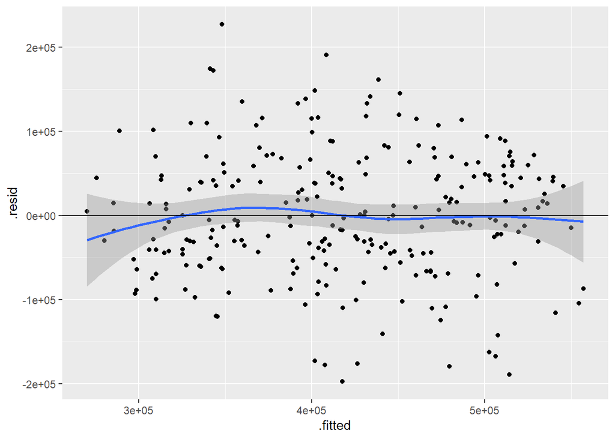

```r
ggplot(model_order, aes(x=.fitted, y=.resid)) +
 geom_point() + geom_smooth()+
 geom_hline(yintercept = 0)
```

No specific pattern is observed. Smooth line is almost a straight line. Linear assumption is met.

### Equal Variance Assumption

$H_0$ : Heteroscedasticity is not present (homoscedasticity) $H_a$ : Heteroscedasticity is present

```r
bptest(model_order)
```

```
##
##  studentized Breusch-Pagan test
##
## data:  model_order
## BP = 8.6056, df = 5, p-value = 0.1259
```

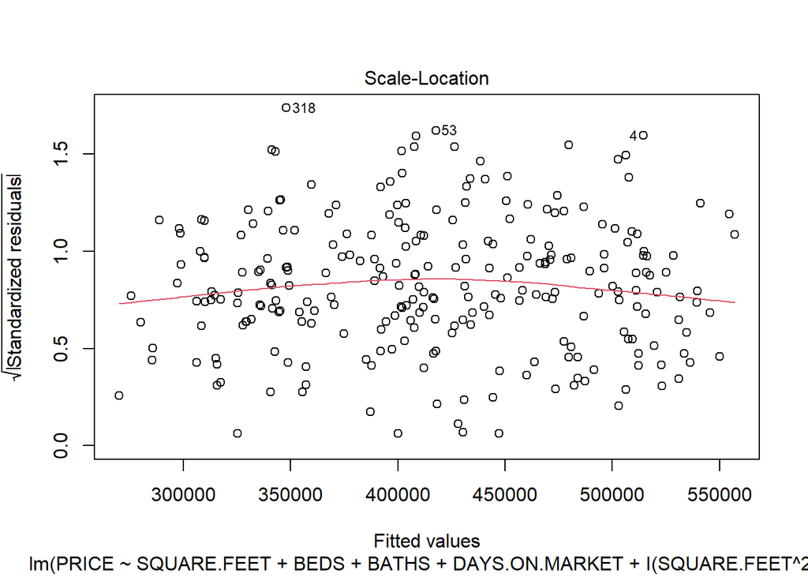

```r
plot(model_order,3)
```

The p-value = 0.1259 > 0.05, indicating that we failed to reject the null hypothesis.  
Therefore, the test provides evidence to suggest that heteroscedasticity does not exist.

### Normality Assumption

$H_0$ : the sample data are significantly normally distributed $H_a$ : the sample data are not significantly normally distributed

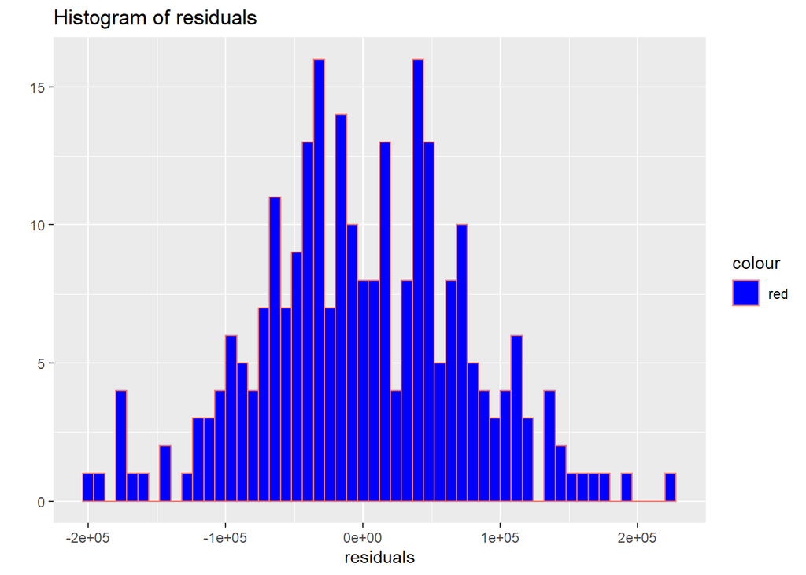

```r
qplot(residuals(model_order),
 geom="histogram",
 binwidth = 8000,
 main = "Histogram of residuals",
 xlab = "residuals", color="red",
 fill=I("blue"))
```

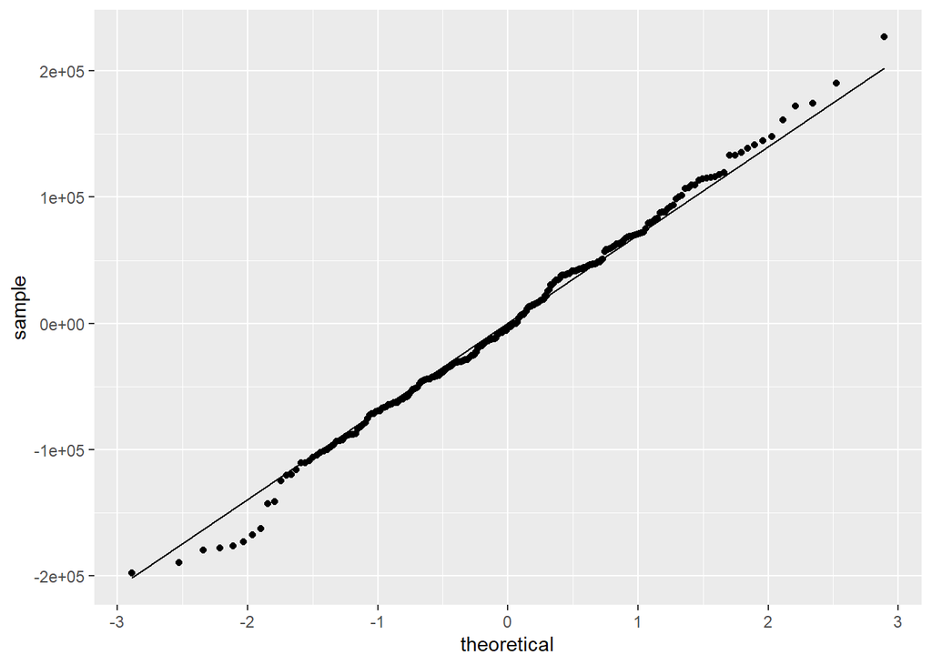

```r
#normal QQ plot
ggplot(train, aes(sample=model_order$residuals)) +
 stat_qq() +
 stat_qq_line()
```

```r
#Shapiro.Wilk test for Normality
shapiro.test(residuals(model_order))
```

```
##
##  Shapiro-Wilk normality test
##
## data:  residuals(model_order)
## W = 0.99609, p-value = 0.7651
```

Residuals lines well around the normal distribution straight line. From the above shapiro-Wilk normality test the p-value = 0.7651 > 0.05 indicates that we failed to reject the null hypothesis. Thus, confirms that the residuals are normally distributed.

### Multi-Collinearity

```r
#fitAllModel <- lm(PRICE~.,data = train)
imcdiag(model_order, method="VIF")
```

```
##
## Call:
## imcdiag(mod = model_order, method = "VIF")
##
##
##  VIF Multicollinearity Diagnostics
##
##                      VIF detection
## SQUARE.FEET      27.7933         1
## BEDS              3.1164         0
## BATHS             1.9811         0
## DAYS.ON.MARKET    1.0475         0
## I(SQUARE.FEET^2) 22.7519         1
##
## Multicollinearity may be due to SQUARE.FEET I(SQUARE.FEET^2) regressors
##
## 1 --> COLLINEARITY is detected by the test
## 0 --> COLLINEARITY is not detected by the test
##
## ===================================
```

```r
#fitAllModel <- lm(PRICE~.,data = train)
imcdiag(lm(PRICE~SQUARE.FEET+BEDS+BATHS+DAYS.ON.MARKET,data=train), method="VIF")
```

```
##
## Call:
## imcdiag(mod = lm(PRICE ~ SQUARE.FEET + BEDS + BATHS + DAYS.ON.MARKET,
##     data = train), method = "VIF")
##
##
##  VIF Multicollinearity Diagnostics
##
##                   VIF detection
## SQUARE.FEET    2.5802         0
## BEDS           3.0377         0
## BATHS          1.9251         0
## DAYS.ON.MARKET 1.0458         0
##
## NOTE:  VIF Method Failed to detect multicollinearity
##
##
## 0 --> COLLINEARITY is not detected by the test
##
## ===================================
```

### Residuals vs Leverage plot

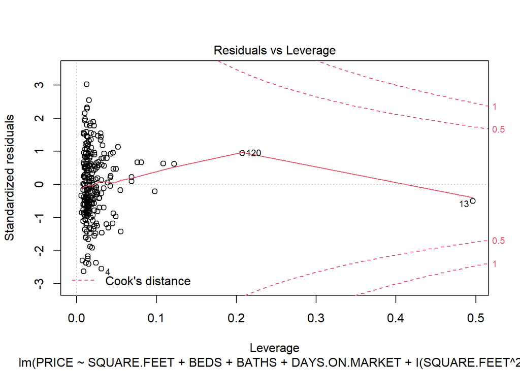

```r
plot(model_order,which=5)
```

### Cook’s Distance

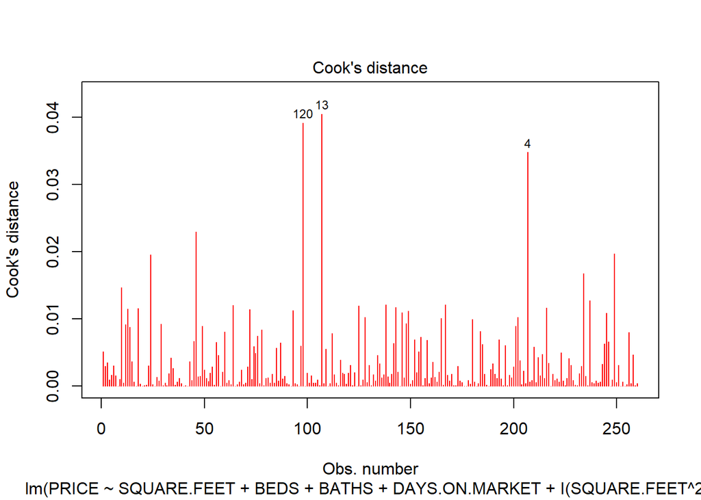

```r
plot(model_order,pch=18,col="red",which=c(4))
```

No data points with Cook’s distance>0.5 is observed.

### Leverage points

```r
lev=hatvalues(model_order)
p = length(coef(model_order))
n = nrow(train)

print("** 2p/n Outliers **")
```

```
## [1] "** 2p/n Outliers **"
```

```r
outlier2p = lev[lev>(2*p/n)]
print(outlier2p)
```

```
##        168        157        120         13        217         31        288
## 0.05173571 0.04925427 0.20743219 0.49620811 0.04631913 0.10836473 0.07616801
##        273         61         56        215          8         87         79
## 0.12193862 0.05463608 0.06890874 0.06869136 0.09802471 0.08076417 0.05516674
##        306
## 0.04908000
```

```r
print("                   ")
```

```
## [1] "                   "
```

```r
print("                   ")
```

```
## [1] "                   "
```

```r
print("** 3p/n Outliers **")
```

```
## [1] "** 3p/n Outliers **"
```

```r
outlier3p = lev[lev>(3*p/n)]
print(outlier3p)
```

```
##        120         13         31        288        273          8         87
## 0.20743219 0.49620811 0.10836473 0.07616801 0.12193862 0.09802471 0.08076417
```

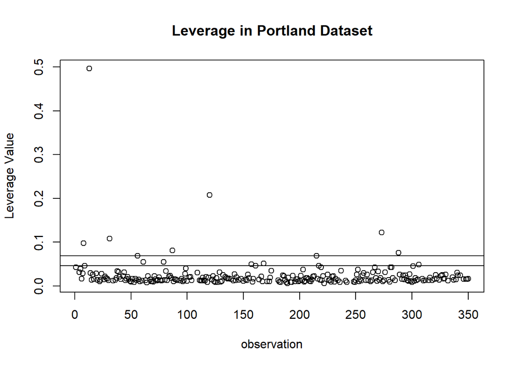

```r
plot(rownames(train),lev, main = "Leverage in Portland Dataset",
xlab="observation",
 ylab = "Leverage Value")
abline(h = 2 *p/n, lty = 1)
abline(h = 3 *p/n, lty = 1)
```

```r
# Remove leverage>2*p/n points
train[which(hatvalues(model_order) > 2 *p/n),]
```

|  | PROPERTY.TYPE | PRICE | BEDS | BATHS | SQUARE.FEET | YEAR.BUILT | DAYS.ON.MARKET |
| --- | --- | --- | --- | --- | --- | --- | --- |
| 168 | Single Family Residential | 545000 | 1 | 0.5 | 1600 | 1952 | 8 |
| 157 | Single Family Residential | 389000 | 4 | 1.0 | 1185 | 1962 | 6 |
| 120 | Single Family Residential | 579900 | 5 | 3.0 | 3327 | 2003 | 5 |
| 13 | Condo/Co-op | 315000 | 1 | 1.0 | 926 | 2001 | 146 |
| 217 | Single Family Residential | 579999 | 4 | 4.0 | 2049 | 1983 | 13 |
| 31 | Single Family Residential | 585000 | 3 | 2.0 | 3010 | 1929 | 1 |
| 288 | Single Family Residential | 549000 | 6 | 3.0 | 2700 | 1960 | 21 |
| 273 | Single Family Residential | 565000 | 5 | 3.0 | 3086 | 1955 | 19 |
| 61 | Multi-Family (2-4 Unit) | 499900 | 5 | 4.0 | 1888 | 1981 | 4 |
| 56 | Single Family Residential | 550000 | 4 | 2.5 | 2889 | 2005 | 4 |

[output cut: 5 more lines]

```r
new_train_1 <- train[-which(hatvalues(model_order) > 2 *p/n),]

str(new_train_1)
```

```
## 'data.frame':    245 obs. of  7 variables:
##  $ PROPERTY.TYPE : chr  "Single Family Residential" "Condo/Co-op" "Single Family Residential" "Condo/Co-op" ...
##  $ PRICE         : int  550000 239000 600000 265000 329000 240000 401900 350000 350000 299900 ...
##  $ BEDS          : int  5 1 3 1 3 1 3 1 3 4 ...
##  $ BATHS         : num  2 1 3 1 2 1 2.5 1 2 2 ...
##  $ SQUARE.FEET   : int  2295 697 1920 592 1115 602 1513 833 1145 1960 ...
##  $ YEAR.BUILT    : int  1956 2007 1939 1949 1970 1966 2021 1909 1959 1958 ...
##  $ DAYS.ON.MARKET: int  8 18 4 12 19 5 5 5 1 6 ...
```

```r
# Remove leverage>3*p/n points
train[which(hatvalues(model_order) > 3 *p/n),]
```

|  | PROPERTY.TYPE | PRICE | BEDS | BATHS | SQUARE.FEET | YEAR.BUILT | DAYS.ON.MARKET |
| --- | --- | --- | --- | --- | --- | --- | --- |
| 120 | Single Family Residential | 579900 | 5 | 3 | 3327 | 2003 | 5 |
| 13 | Condo/Co-op | 315000 | 1 | 1 | 926 | 2001 | 146 |
| 31 | Single Family Residential | 585000 | 3 | 2 | 3010 | 1929 | 1 |
| 288 | Single Family Residential | 549000 | 6 | 3 | 2700 | 1960 | 21 |
| 273 | Single Family Residential | 565000 | 5 | 3 | 3086 | 1955 | 19 |
| 8 | Single Family Residential | 535000 | 5 | 4 | 2796 | 1930 | 33 |
| 87 | Multi-Family (2-4 Unit) | 479900 | 6 | 3 | 1612 | 1981 | 4 |

```r
new_train_2 <- train[-which(hatvalues(model_order) > 3 *p/n),]

str(new_train_2)
```

```
## 'data.frame':    253 obs. of  7 variables:
##  $ PROPERTY.TYPE : chr  "Single Family Residential" "Condo/Co-op" "Single Family Residential" "Condo/Co-op" ...
##  $ PRICE         : int  550000 239000 600000 265000 329000 240000 401900 350000 350000 299900 ...
##  $ BEDS          : int  5 1 3 1 3 1 3 1 3 4 ...
##  $ BATHS         : num  2 1 3 1 2 1 2.5 1 2 2 ...
##  $ SQUARE.FEET   : int  2295 697 1920 592 1115 602 1513 833 1145 1960 ...
##  $ YEAR.BUILT    : int  1956 2007 1939 1949 1970 1966 2021 1909 1959 1958 ...
##  $ DAYS.ON.MARKET: int  8 18 4 12 19 5 5 5 1 6 ...
```

```r
#Use data removed leverage>2p/n to fit the model
model_order_no_2p <- lm(PRICE~SQUARE.FEET+BEDS+BATHS+DAYS.ON.MARKET+I(SQUARE.FEET^2),data=new_train_1)
summary(model_order_no_2p)
```

```
##
## Call:
## lm(formula = PRICE ~ SQUARE.FEET + BEDS + BATHS + DAYS.ON.MARKET +
##     I(SQUARE.FEET^2), data = new_train_1)
##
## Residuals:
##     Min      1Q  Median      3Q     Max
## -199382  -47765   -2735   51854  223294
##
## Coefficients:
##                    Estimate Std. Error t value Pr(>|t|)
## (Intercept)       1.294e+05  3.479e+04   3.720 0.000249 ***
## SQUARE.FEET       3.205e+02  5.716e+01   5.606 5.68e-08 ***
## BEDS             -2.455e+04  8.202e+03  -2.993 0.003056 **
## BATHS             2.885e+04  9.986e+03   2.889 0.004217 **
## DAYS.ON.MARKET   -9.524e+00  5.956e+02  -0.016 0.987254
## I(SQUARE.FEET^2) -6.305e-02  1.777e-02  -3.548 0.000467 ***
## ---
## Signif. codes:  0 '***' 0.001 '**' 0.01 '*' 0.05 '.' 0.1 ' ' 1
##
## Residual standard error: 76710 on 239 degrees of freedom
## Multiple R-squared:  0.4503, Adjusted R-squared:  0.4388
## F-statistic: 39.16 on 5 and 239 DF,  p-value: < 2.2e-16
```

```r
#Use data removed leverage>3p/n to fit the model
model_order_no_3p <- lm(PRICE~SQUARE.FEET+BEDS+BATHS+DAYS.ON.MARKET+I(SQUARE.FEET^2),data=new_train_2)
summary(model_order_no_3p)
```

```
##
## Call:
## lm(formula = PRICE ~ SQUARE.FEET + BEDS + BATHS + DAYS.ON.MARKET +
##     I(SQUARE.FEET^2), data = new_train_2)
##
## Residuals:
##     Min      1Q  Median      3Q     Max
## -200569  -48629   -3254   51359  223725
##
## Coefficients:
##                    Estimate Std. Error t value Pr(>|t|)
## (Intercept)       1.278e+05  3.223e+04   3.965 9.60e-05 ***
## SQUARE.FEET       3.249e+02  5.178e+01   6.275 1.55e-09 ***
## BEDS             -2.421e+04  7.781e+03  -3.111  0.00208 **
## BATHS             2.847e+04  9.238e+03   3.082  0.00229 **
## DAYS.ON.MARKET   -5.905e+01  5.847e+02  -0.101  0.91964
## I(SQUARE.FEET^2) -6.479e-02  1.542e-02  -4.203 3.69e-05 ***
## ---
## Signif. codes:  0 '***' 0.001 '**' 0.01 '*' 0.05 '.' 0.1 ' ' 1
##
## Residual standard error: 76060 on 247 degrees of freedom
## Multiple R-squared:  0.4597, Adjusted R-squared:  0.4488
## F-statistic: 42.03 on 5 and 247 DF,  p-value: < 2.2e-16
```

Using data sets removed points with leverage 2*p/n and 3*p/n give lower adj-R2 than original train data. Will keep the high leverage points.

## Prediction

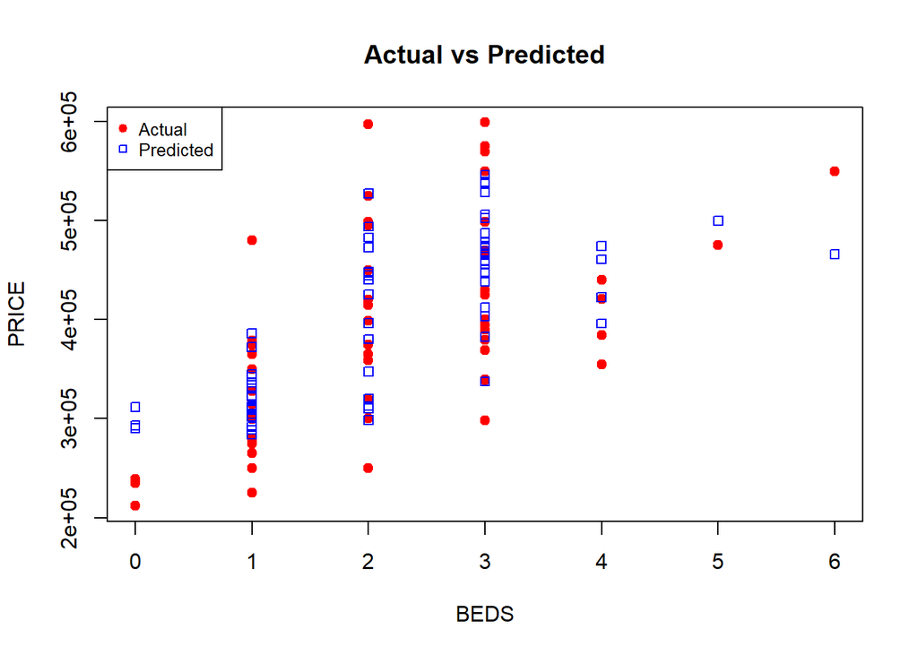

```r
predict20 = predict.lm(model_order, newdata=test)

plot(PRICE~BEDS, data = test, col="red", pch=19, main="Actual vs Predicted")
points(test$BEDS, predict20, col="blue", pch=22)
legend("topleft", legend=c("Actual", "Predicted"), col=c("red", "blue"), pch=c(19,22), cex = 0.8)
```

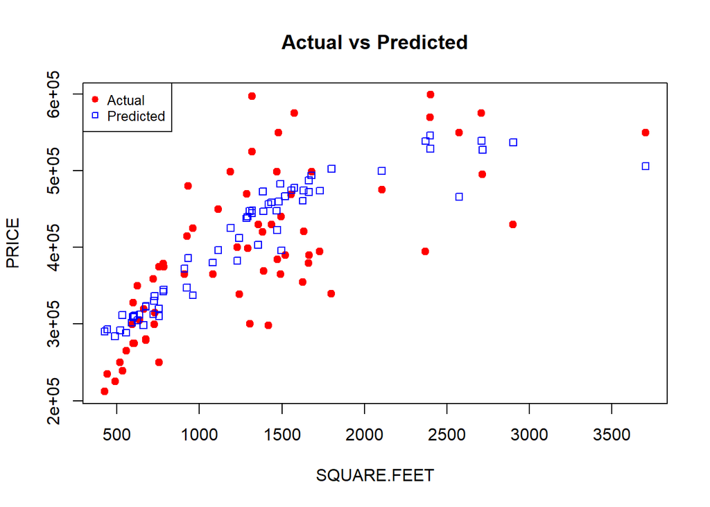

```r
plot(PRICE~SQUARE.FEET, data = test, col="red", pch=19, main="Actual vs Predicted")
points(test$SQUARE.FEET, predict20, col="blue", pch=22)
legend("topleft", legend=c("Actual", "Predicted"), col=c("red", "blue"), pch=c(19,22), cex = 0.8)
```

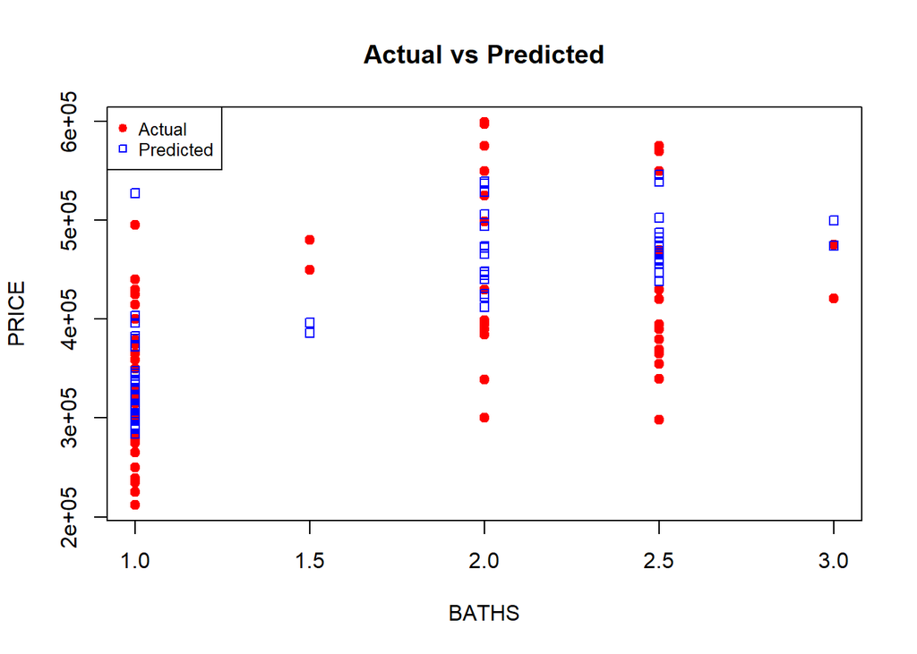

```r
plot(PRICE~BATHS, data = test, col="red", pch=19, main="Actual vs Predicted")
points(test$BATHS, predict20, col="blue", pch=22)
legend("topleft", legend=c("Actual", "Predicted"), col=c("red", "blue"), pch=c(19,22), cex = 0.8)
```

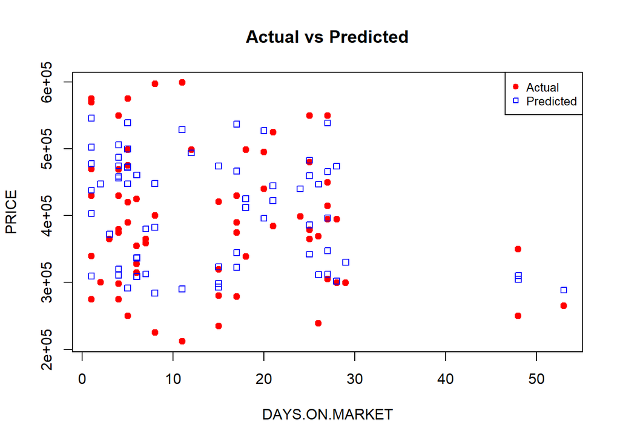

```r
plot(PRICE~DAYS.ON.MARKET, data = test, col="red", pch=19, main="Actual vs Predicted")
points(test$DAYS.ON.MARKET, predict20, col="blue", pch=22)
legend("topright", legend=c("Actual", "Predicted"), col=c("red", "blue"), pch=c(19,22), cex = 0.8)
```

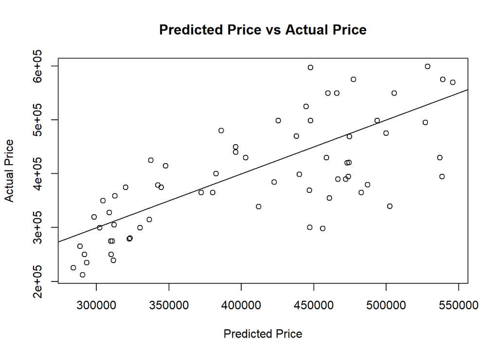

```r
plot(predict20, test$PRICE, main="Predicted Price vs Actual Price", xlab="Predicted Price", ylab="Actual Price")
abline(a=0, b=1)
```

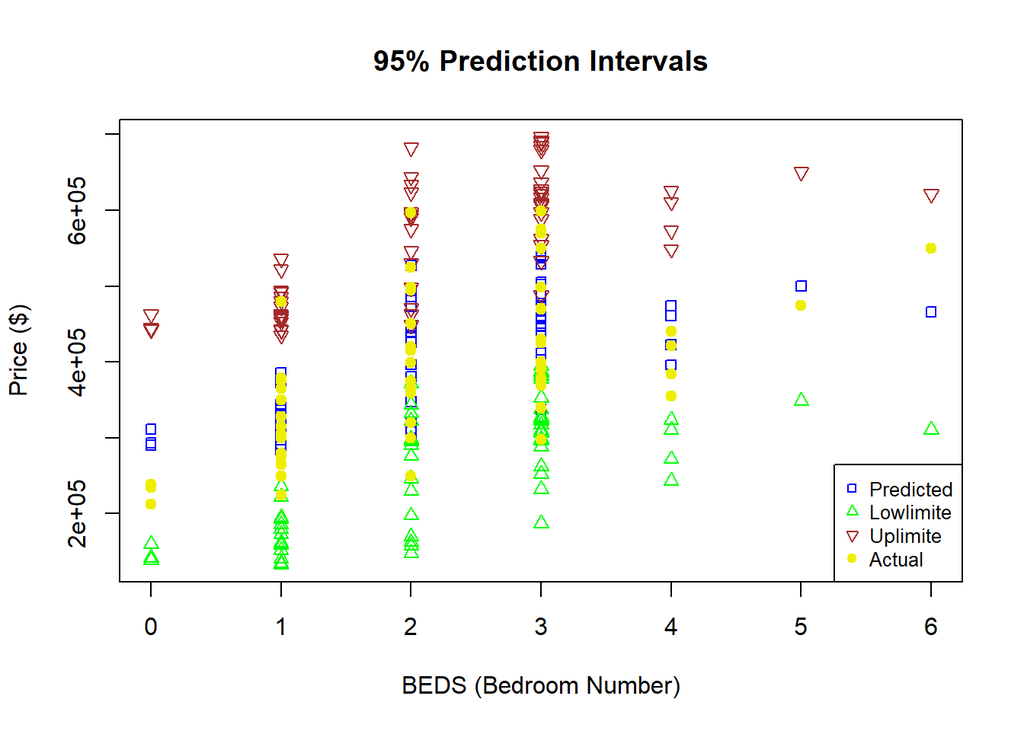

```r
mape = mean(abs((test$PRICE - predict20)/test$PRICE))

predict20pred = predict.lm(model_order, newdata=test, level=0.95, interval = "prediction")

matplot(test$BEDS, predict20pred, pch=c(22, 2, 6), col=c("blue", "green", "brown"), main="95% Prediction Intervals", xlab="BEDS (Bedroom Number)", ylab="Price ($)")
points(test$BEDS, test$PRICE, col="yellow2", pch=19)
legend ("bottomright", legend=c ("Predicted", "Lowlimite", "Uplimite", "Actual"),
col=c("blue", "green", "brown", "yellow2"), pch=c(22, 2, 6, 19), cex=0.8)
```

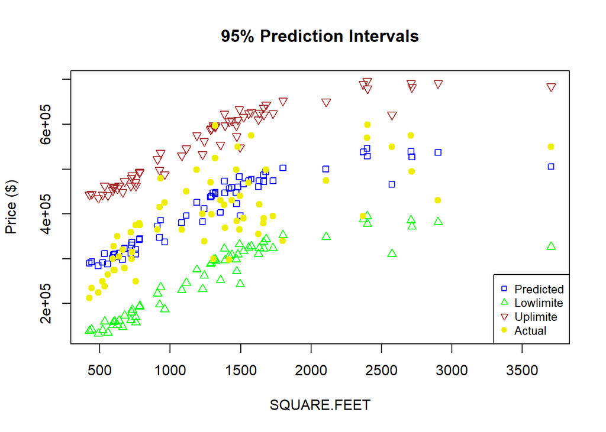

```r
matplot(test$SQUARE.FEET, predict20pred, pch=c(22, 2, 6), col=c("blue", "green", "brown"), main="95% Prediction Intervals", xlab="SQUARE.FEET", ylab="Price ($)")
points(test$SQUARE.FEET, test$PRICE, col="yellow2", pch=19)
legend ("bottomright", legend=c ("Predicted", "Lowlimite", "Uplimite", "Actual"),
col=c("blue", "green", "brown", "yellow2"), pch=c(22, 2, 6, 19), cex=0.8)
```

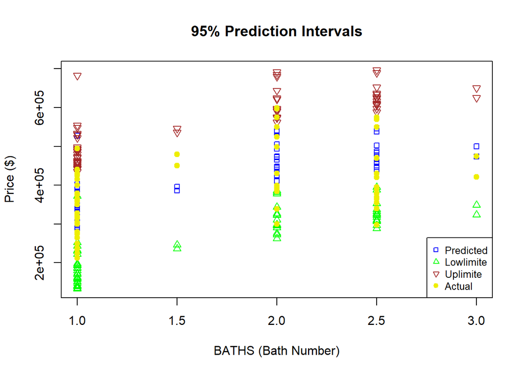

```r
matplot(test$BATHS, predict20pred, pch=c(22, 2, 6), col=c("blue", "green", "brown"), main="95% Prediction Intervals", xlab="BATHS (Bath Number)", ylab="Price ($)")
points(test$BATHS, test$PRICE, col="yellow2", pch=19)
legend ("bottomright", legend=c ("Predicted", "Lowlimite", "Uplimite", "Actual"),
col=c("blue", "green", "brown", "yellow2"), pch=c(22, 2, 6, 19), cex=0.8)
```

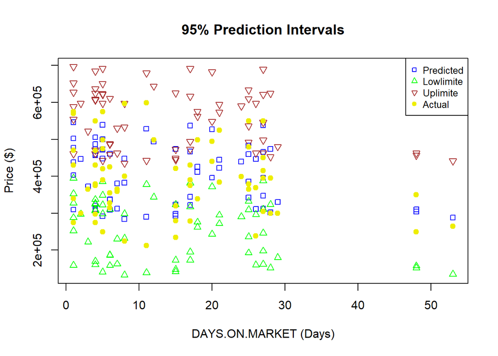

```r
matplot(test$DAYS.ON.MARKET, predict20pred, pch=c(22, 2, 6), col=c("blue", "green", "brown"), main="95% Prediction Intervals", xlab="DAYS.ON.MARKET (Days)", ylab="Price ($)")
points(test$DAYS.ON.MARKET, test$PRICE, col="yellow2", pch=19)
legend ("topright", legend=c ("Predicted", "Lowlimite", "Uplimite", "Actual"),
col=c("blue", "green", "brown", "yellow2"), pch=c(22, 2, 6, 19), cex=0.8)
```

Predicted Price vs. Actual Price sit along the straight line with slope=1.  
Actual price fall between the upper and lower limit of 95% confidence interval.